# Series: The 100

Adam Gonet

2026-05-09

## About the Series

*The 100* is an American post-apocalyptic science fiction drama developed by *Jason Rothenberg*. The show is loosely based on the novel series written by *Kass Morgan*.

The story begins ninety-seven years after a devastating nuclear apocalypse wiped out almost all life on Earth. The only known survivors lived on a massive space station known as the ‘Ark’. Facing failing life-support systems, the Ark’s leaders send 100 juvenile delinquents down to the surface to determine if Earth has become habitable again.

As these teens, including *Clarke Griffin*, *Bellamy Blake*, *Octavia Blake*, and *Raven Reyes*, struggle to survive the harsh conditions of the ground, they soon discover they are not alone. They must navigate complex relationships and moral dilemmas while encountering groups such as the *Grounders*, *Mountain Men*, and various factions vying for survival in a reclaimed world.

Over the course of seven seasons, *The 100* explores themes of survival, sacrifice, and the lengths humanity will go to in order to ensure its future.

[figure not shown]

[figure not shown]

# Viewership Statistics

The series debuted on March 19, 2014, with a strong pilot episode that garnered **2.73 million** viewers. Over its seven-season run, the show transitioned from a high-stakes survival drama to a complex exploration of tribalism, technology, and morality.

[output not shown]

# Viewership Over Time

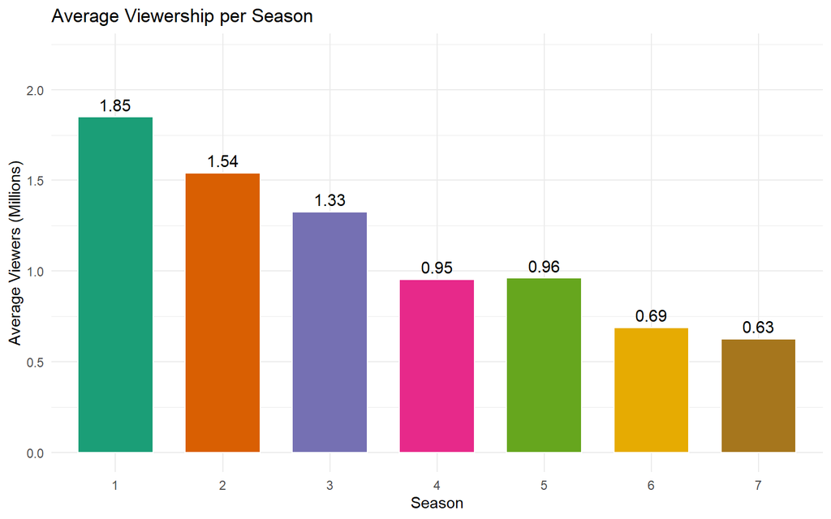

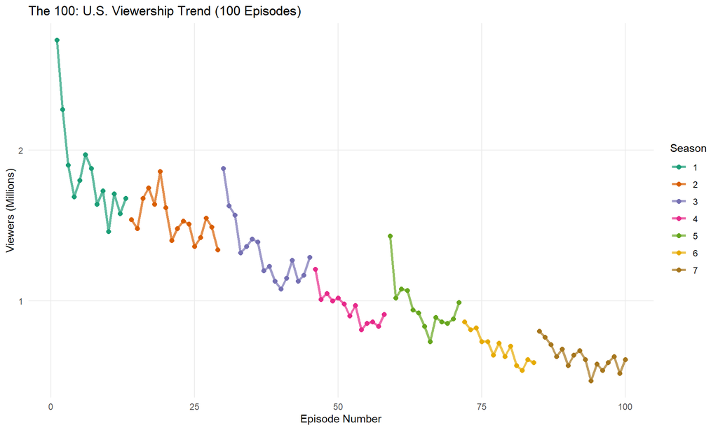

The graph above tracks the U.S. viewership (in millions) for every episode of the series. While there is a clear downward trend common in long-running cable dramas, the show maintained a dedicated cult following.

The series peaked with the **Pilot (2.73 million)** and concluded with **0.61 million**. However, the curve flattens significantly after Season 4, indicating that while the show lost casual viewers, it successfully retained a loyal core audience.

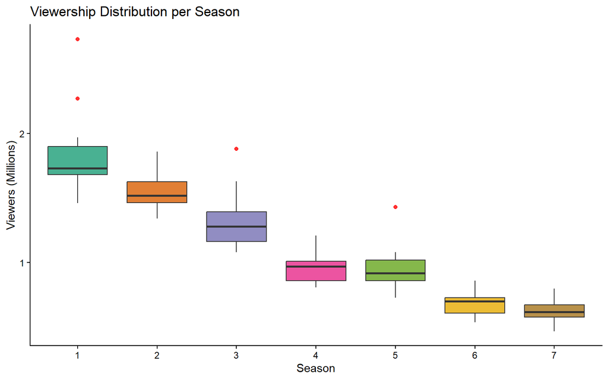

The **Boxplot** provides insights into audience reliability:

- **Seasons 1-3:** High medians and high variance suggest a show finding its footing.
- **Seasons 4-5:** A “correction” period with smaller variance, reflecting critical reception.
- **Seasons 6-7:** Small “boxes” suggest a stabilized niche audience. Fans who watched these seasons were highly dedicated and unlikely to drop the series before the end.

# Ratings over episodes

| Top Rated Episode | Top Rated IMDb Rating |  | Bottom Rated Episode | Bottom Rated IMDb Rating |
| --- | --- | --- | --- | --- |
| S05E13 | 9.5 |  | S07E13 | 4.8 |
| S02E16 | 9.2 |  | S07E14 | 6.1 |
| S04E10 | 9.1 |  | S07E15 | 6.4 |
| S04E13 | 9.1 |  | S07E16 | 6.7 |
| S07E08 | 9.0 |  | S03E07 | 6.9 |

[figure not shown]

The heatmap above visualizes the critical reception of each episode across all seasons, based on IMDb ratings. The color gradient from dark brown (lower ratings) to gold (higher ratings) allows for quick identification of standout episodes and trends in quality throughout the series. Notably, Season 5 contains some of the highest-rated episodes, while Season 7 shows a significant drop in ratings, particularly towards the end.

The visualization highlights the show’s “Finale Strength,” with standout episodes such as **S05E13** and **S02E16** receiving universal acclaim. In fact, the series reached its critical peak with a rating of **9.5**.

Conversely, it captures the controversy of the final season, specifically **S07E13**, which represents the lowest point in series reception with a rating of **4.8**. This demonstrates a significant disparity between the show’s creative heights and its most divisive moments, as seen in the gap of **4.7** points between the best and worst rated episodes.